# Introducción a distribuciones de probabilidad

Ramon Ceballos

7/2/2021

# **Distribución Geométrica**

## 1. Conceptos teóricos y matemáticos

Si **$X$** es variable aleatoria que mide el “número de repeticiones independientes del experimento (tipo Bernoulli) hasta haber conseguido el primer éxito”, entonces diremos que **$X$** se distribuye como una Geométrica con un solo parámetro **$p$**. Otra forma de definir esta distribución es como el nº de intentos necesarios hasta conseguir éxito. Esta función depende de si se cuenta el nº de intentos o el nº de fracasos hasta obtener el éxito.

$$X\sim \text{Ge}(p)$$

En esta expresión, **$p$** es la probabilidad de éxito y **$q = 1-p$** es la probabilidad de fracaso.

Ejemplos de este tipo de distribuciones es cuando un borracho prueba a abrir la puerta de su casa teninedo un manojo de $n$ llaves distintas, o la probabilidad de tener un hijo en función de los intentos($n$ intentos).

Vamos a definir algunas de las propiedades que tendrá una distribución Geométrica.

- El **dominio** de $X$ será $D_X= \{0,1,2,\dots\}$ (si contamos el nº de fracasos hasta obtener el primer éxito, por ello se incluye el 0) o bien $D_X = \{1,2,\dots\}$ (aquí se cuentan el nº de intentos de ahí que se empiece por 1) en función de si empieza en 0 o en 1, respectivamente.
- La **función de probabilidad** vendrá dada por:
  $$f(k) = (1-p)^{k}p \qquad\text{ si empieza en 0}$$
  $$f(k) = (1-p)^{k-1}p \qquad\text{ si empieza en 1}$$
- La **función de distribución** vendrá dada por:
  $$F(x) = \left\{
  \begin{array}{cl}
  0 & \text{si } x<0
  \\ 1-(1-p)^{k+1} & \text{si } k\le x<k+1,\ k\in\mathbb{N}
  \end{array}
  \right.$$

En este caso, dependerá de si se cuenta el nº de intentos o de fracasos. Cuando $k$ tiende a infinito la probabilidad va bajando paulatinamente.

- **Esperanza**. $E(X) = \frac{1-p}{p}$ si empieza en 0 y E$(X) = \frac{1}{p}$ si empieza en 1.
- **Varianza**. $Var(X) = \frac{1-p}{p^2}$
- **Propiedad de la falta de memoria**. Si $X$ es una v.a. $\text{Ge}(p)$, entonces:
  $$p\{X\ge m+n:\ X\ge n\} = p\{X\ge m\}\ \forall m,n=0,1,\dots$$

En este caso, la probabilidad de éxito es independiente del nº de intentos.

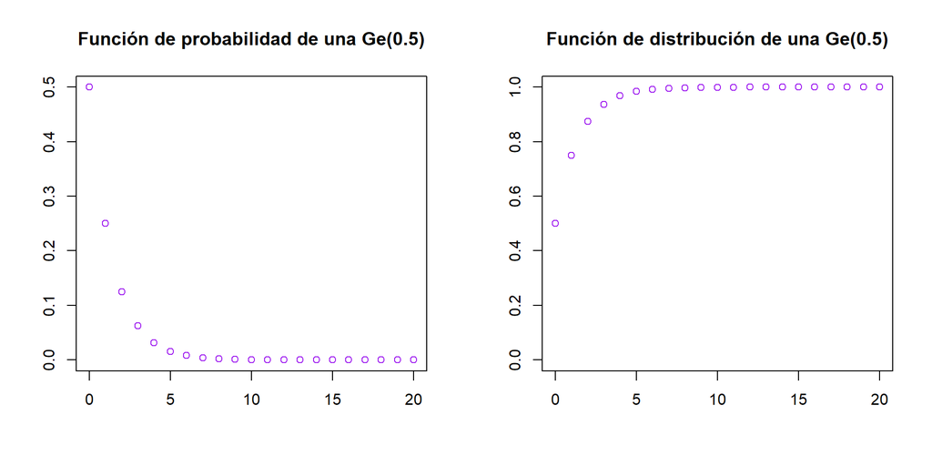

```r
par(mfrow = c(1,2))
plot(0:20, dgeom(0:20,0.5),col = "purple", xlab = "", ylab = "", main = "Función de probabilidad de una Ge(0.5)")
plot(0:20, pgeom(0:20,0.5),col = "purple", xlab = "", ylab = "", main = "Función de distribución de una Ge(0.5)", ylim = c(0,1))
```

```r
par(mfrow= c(1,1))
```

## 2. Distribución Geométrica en `R` y `Python`

El código de la distribución Geométrica:

- En **`R`** tenemos las funciones del paquete `Rlab`: **`dgeom(x, prob), pgeom(q, prob), qgeom(p, prob), rgeom(n, prob)`** donde `prob` es la probabilidad de éxito del experimento.
- En **`Python`** tenemos las funciones del paquete **`scipy.stats.geom`**: `pmf(k,p), cdf(k,p), ppf(q,p), rvs(p, size)` donde `p` es la probabilidad de éxito del experimento.

## 3. Ejemplos en código para la distribución Geométrica (R y Python)

Si el borracho tuviera 10 llaves entonces para modelizar la distribución geométrica la probabilidad debería de ser de 0.1.

Sea $X=Geom(p=0.1)$ la distribución que modela la probabilidad de intentar abrir una puerta hasta conseguirlo. En este caso la función de probabilidad del nº de intentos sería:

#### **Ejemplo en R**

Empleamos las funciones anteriores.

```r
library(Rlab)
```

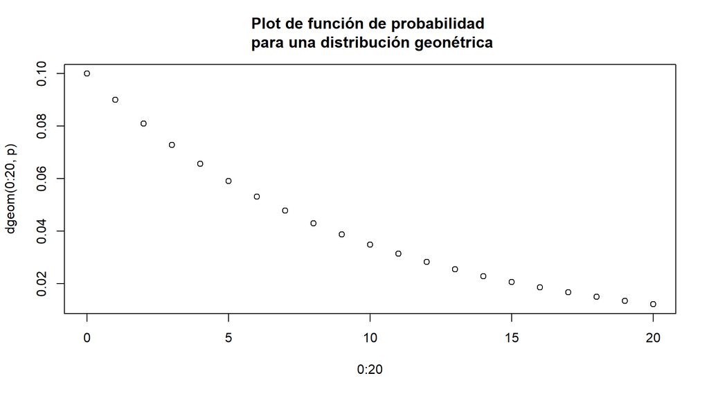

```r
#defino la proabilidad
p = 0.1

#Función de probabilidad para 20 intentos
plot(0:20, dgeom(0:20, p),
     title("Plot de función de probabilidad \n para una distribución geonétrica"))
```

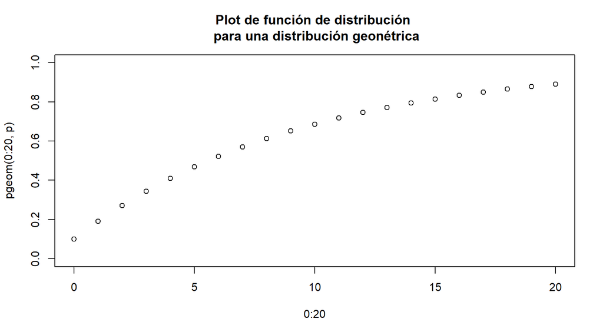

```r
#Función de distribución para 20 intentos
plot(0:20, pgeom(0:20, p),
     ylim = c(0,1), #Acaba en 1 siempre
     title("Plot de función de distribución \n para una distribución geonétrica"))
```

```r
#La mediana
qgeom(0.5, p)
```

```
## [1] 6
```

```r
#El cuantil 0.75
qgeom(0.75, p)
```

```
## [1] 13
```

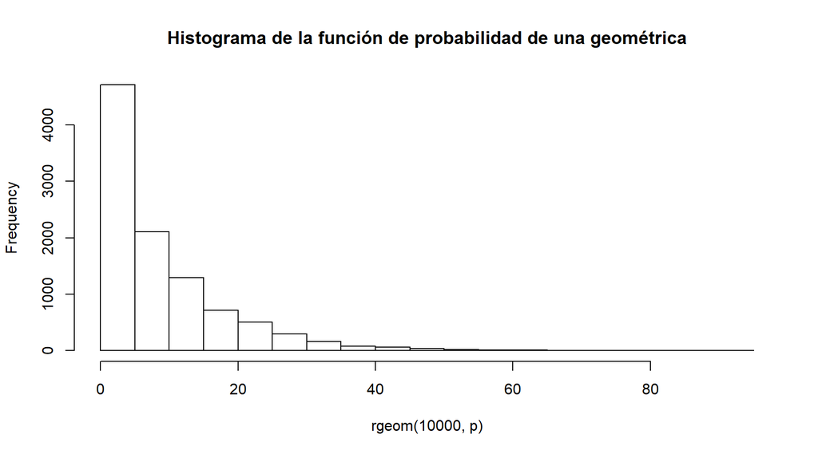

```r
#Valores aleatorios generados con rgeom
#Representación en histograma
hist(rgeom(10000, p),
     main = "Histograma de la función de probabilidad de una geométrica")
```

#### **Ejemplo en Python**

Vete al script de Python del presente tema 7.